# Evaluación 1 - Diplomado Data Science Duoc UC

# Módulo: Machine Learning

A continuación, aplicarás lo aprendido con el uso de las librerías de Python desde fuentes de datos proporcionadas por el relator.

**Recuerda almacenar una copia de este Jupyter Notebook en tu Google Drive para poder ejecutar los bloques de código.**

- Ejecución técnica de un procedimiento de Análisis Exploratorio de datos
  - Deberá cargar los datos del CSV a pandas
  - Deberá identificar las columnas relevantes y realizar la unión de los datos
  - Deberá identificar las columnas más relevantes del negocio y proponer una rutina de limpieza
  - Separar la información entre las columnas relevantes y ejecutar su rutina de limpieza
  - Identificar la correlación de las columnas e identificar las más relevantes
  - Proponga 5 gráficos que otorguen valor a los datos y describa el conocimiento que puede extraer de éstos

# Contexto:

Una empresa anónima, nos encargó la importante misión de predecir como serán sus próximas ventas basados en sus datos transaccionales. Para falicitar el proyecto de Análisis de Datos, nos proporcionó 3 datasets que necesitaremos relacionar para poder responder a la demanda de nuestro cliente. La primera fase de nuestro proyecto consistirá en un análisis exploratorio que nos permitirá conocer del negocio, saber qué venden, cuantos clientes manejan en sus sistemas, entre otras preguntas relevantes que nos permitirán plantear diversas hipótesis respecto de los datos.

**Recuerda hacer uso de todo lo aprendido! mientras más cosas descubras de los datos, más robusto será tu análisis.**

# Análisis Exploratorio de Datos

## Importar las librerias necesarias

```python
# Importe las librerias necesarias para trabajar aquí
import numpy as np
import pandas as pd
import seaborn as sbn
import matplotlib.pyplot as plt
import re as re

# data = datamart.merge(clientes, left_on="id_cliente",right_on="id_cliente", how="left")
```

## Cargar fuentes de datos

```python
# Cargue los archivos CSV necesarios aquí
datamart = pd.read_csv('datamart.csv') #Carga datamart.csv
clientes = pd.read_csv('datos_clientes.csv') #Carga datos_clientes.csv
trabajadores = pd.read_csv('datos_trabajador.csv') #Carga datos_trabajador.csv
ventas = pd.read_csv('datos_ventas.csv',sep='|') #Carga datos_ventas.csv
```

```python
# Realice análisis de los datos del CSV 1
clientes.head()
```

|  | id_cliente | primer_nombre | apellido_paterno | apellido_materno | correo | genero | idioma | estado_civil | cant_hijos | edad | estudios | Color_F |
| --- | --- | --- | --- | --- | --- | --- | --- | --- | --- | --- | --- | --- |
| 0 | 1 | Ibby | Plewes | Izac | iizac0@cnbc.com | Female | Lithuanian | Otro | 1 | 1 | RMA | Celeste |
| 1 | 2 | Doralia | Ewell | Townsend | dtownsend1@ow.ly | Female | Armenian | Viudo | 2 | 2 | IEX Total View | Azul |
| 2 | 3 | Lynette | Merrydew | Feaveryear | lfeaveryear2@aol.com | Female | Papiamento | Soltero | 3 | 3 | RMI | Celeste |
| 3 | 4 | Janaye | Jeffryes | Anglim | janglim3@ameblo.jp | Female | Georgian | Casado | 4 | 4 | MTP3 | Azul |
| 4 | 5 | Travus | Divis | Minchindon | tminchindon4@sourceforge.net | Male | Northern Sotho | Casado | 1 | 5 | RMI | Amarrillo |

```python
print("------------------------------------")
print("Forma de la tabla")
print("------------------------------------")
print(clientes.shape)
print("------------------------------------")
print("Descripción de tipos de datos")
print("------------------------------------")
print(clientes.info())
print("------------------------------------")
print("Promedios y estadísticas básicas")
print("------------------------------------")
print(clientes.describe())
```

```
------------------------------------
Forma de la tabla
------------------------------------
(500, 12)
------------------------------------
Descripción de tipos de datos
------------------------------------
<class 'pandas.core.frame.DataFrame'>
RangeIndex: 500 entries, 0 to 499
Data columns (total 12 columns):
 #   Column            Non-Null Count  Dtype
---  ------            --------------  -----
 0   id_cliente        500 non-null    int64
 1   primer_nombre     500 non-null    object
 2   apellido_paterno  500 non-null    object
 3   apellido_materno  500 non-null    object
 4   correo            500 non-null    object
 5   genero            500 non-null    object
 6   idioma            500 non-null    object
 7   estado_civil      500 non-null    object
 8   cant_hijos        500 non-null    int64
 9   edad              500 non-null    int64
 10  estudios          500 non-null    object
 11  Color_F           500 non-null    object
dtypes: int64(3), object(9)
memory usage: 47.0+ KB
None
------------------------------------
Promedios y estadísticas básicas
------------------------------------
       id_cliente  cant_hijos        edad
count  500.000000  500.000000  500.000000
mean   250.500000    2.500000   32.100000
std    144.481833    1.119154   18.557445
min      1.000000    1.000000    1.000000
25%    125.750000    1.750000   16.000000
50%    250.500000    2.500000   32.000000
75%    375.250000    3.250000   48.000000
max    500.000000    4.000000   65.000000
```

## En el dataset de clientes no hay valores nulos. Información 100% íntegra

```python
# Realice análisis de los datos del CSV 2
trabajadores.head()
```

|  | ID | CAJERO_ID | NOMBRE | APELLIDO | RUT |
| --- | --- | --- | --- | --- | --- |
| 0 | 1 | 2 | Zelda | Wiggins | 23730488-8 |
| 1 | 2 | 3 | Kaye | Bird | 18659842-3 |
| 2 | 3 | 4 | Sean | Tucker | 12534101-2 |
| 3 | 4 | 5 | Ulric | Lester | 14004608-6 |
| 4 | 5 | 7 | Hunter | Booth | 13030165-7 |

```python
print("------------------------------------")
print("Forma de la tabla")
print("------------------------------------")
print(trabajadores.shape)
print("------------------------------------")
print("Descripción de tipos de datos")
print("------------------------------------")
print(trabajadores.info())
```

```
------------------------------------
Forma de la tabla
------------------------------------
(5, 5)
------------------------------------
Descripción de tipos de datos
------------------------------------
<class 'pandas.core.frame.DataFrame'>
RangeIndex: 5 entries, 0 to 4
Data columns (total 5 columns):
 #   Column     Non-Null Count  Dtype
---  ------     --------------  -----
 0   ID         5 non-null      int64
 1   CAJERO_ID  5 non-null      int64
 2   NOMBRE     5 non-null      object
 3   APELLIDO   5 non-null      object
 4   RUT        5 non-null      object
dtypes: int64(2), object(3)
memory usage: 328.0+ bytes
None
```

```python
# Realice análisis de los datos del CSV 3
ventas.head()
```

|  | VENTA_ID | CAJERO_ID | COMPRADOR_ID | FECHA_VENTA | MONTO_TOTAL | CODIGO_PRODUCTO | NOMBRE_PRODUCTO | CODIGO_FAMILIA | NOMBRE_FAMILIA | CANTIDAD |
| --- | --- | --- | --- | --- | --- | --- | --- | --- | --- | --- |
| 0 | 26 | 7 | 32 | 22/08/19 19:43:18,000000000 | Q.-1500. | 7802215104855 | Costa Rama | 4 | CONFITES-GALLETAS | 1,0 |
| 1 | 49 | 7 | 91 | 23/08/19 14:08:25,000000000 | Q.4050-. | 7801810712663 | LIPTON YELLOW 40g. 20UN. | 1 | OFERTAS ESPECIALES | 1,0 |
| 2 | 49 | 7 | 399 | 23/08/19 14:08:25,000000000 | Q.4050-. | 7802575006035 | CORBATAS CARO.400g. | 1 | OFERTAS ESPECIALES | 1,0 |
| 3 | 49 | 7 | 92 | 23/08/19 14:08:25,000000000 | Q.4050-. | 7801875032010 | TÉ SUPREMO 40g. 20UN. | 1 | OFERTAS ESPECIALES | 1,0 |
| 4 | 49 | 7 | 177 | 23/08/19 14:08:25,000000000 | Q.4050-. | 7808743601934 | ACEITE MERKAT 900ml. | 1 | OFERTAS ESPECIALES | 1,0 |

```python
print("------------------------------------")
print("Forma de la tabla")
print("------------------------------------")
print(ventas.shape)
print("------------------------------------")
print("Descripción de tipos de datos")
print("------------------------------------")
print(ventas.info())
print("------------------------------------")
print("Promedios y estadísticas básicas")
print("------------------------------------")
print(ventas.describe())
```

```
------------------------------------
Forma de la tabla
------------------------------------
(1753, 10)
------------------------------------
Descripción de tipos de datos
------------------------------------
<class 'pandas.core.frame.DataFrame'>
RangeIndex: 1753 entries, 0 to 1752
Data columns (total 10 columns):
 #   Column           Non-Null Count  Dtype
---  ------           --------------  -----
 0   VENTA_ID         1753 non-null   int64
 1   CAJERO_ID        1753 non-null   int64
 2   COMPRADOR_ID     1753 non-null   int64
 3   FECHA_VENTA      1753 non-null   object
 4   MONTO_TOTAL      1753 non-null   object
 5   CODIGO_PRODUCTO  1753 non-null   object
 6   NOMBRE_PRODUCTO  1753 non-null   object
 7   CODIGO_FAMILIA   1753 non-null   int64
 8   NOMBRE_FAMILIA   1753 non-null   object
 9   CANTIDAD         1753 non-null   object
dtypes: int64(4), object(6)
memory usage: 137.1+ KB
None
------------------------------------
Promedios y estadísticas básicas
------------------------------------
           VENTA_ID    CAJERO_ID  COMPRADOR_ID  CODIGO_FAMILIA
count   1753.000000  1753.000000   1753.000000     1753.000000
mean    4988.726184     3.828865    249.451797        4.426127
std     6754.533366     2.322299    145.613872        4.225431
min       26.000000     2.000000      1.000000        1.000000
25%     1311.000000     2.000000    123.000000        1.000000
50%     2817.000000     2.000000    246.000000        1.000000
75%     6065.000000     7.000000    378.000000        7.000000
max    62325.000000     7.000000    500.000000       13.000000
```

## Valores 100% integros

## Unir los CSV

```python
# Unir los CSV aquí
# Mergeamos las ventas con el cajero que realizó la venta
data = ventas.merge(trabajadores, left_on="CAJERO_ID",right_on="CAJERO_ID", how="left")
data = data.merge(clientes, left_on='COMPRADOR_ID', right_on='id_cliente', how='left')
data.head()
```

|  | VENTA_ID | CAJERO_ID | COMPRADOR_ID | FECHA_VENTA | MONTO_TOTAL | CODIGO_PRODUCTO | NOMBRE_PRODUCTO | CODIGO_FAMILIA | NOMBRE_FAMILIA | CANTIDAD | ... | apellido_paterno | apellido_materno | correo | genero | idioma | estado_civil | cant_hijos | edad | estudios | Color_F |
| --- | --- | --- | --- | --- | --- | --- | --- | --- | --- | --- | --- | --- | --- | --- | --- | --- | --- | --- | --- | --- | --- |
| 0 | 26 | 7 | 32 | 22/08/19 19:43:18,000000000 | Q.-1500. | 7802215104855 | Costa Rama | 4 | CONFITES-GALLETAS | 1,0 | ... | Palia | Pretsel | jpretselv@army.mil | Male | Pashto | Viudo | 4 | 32 | Adobe Creative Suite | Azul |
| 1 | 49 | 7 | 91 | 23/08/19 14:08:25,000000000 | Q.4050-. | 7801810712663 | LIPTON YELLOW 40g. 20UN. | 1 | OFERTAS ESPECIALES | 1,0 | ... | Quaife | Maude | dmaude2i@meetup.com | Female | Dhivehi | Casado | 3 | 26 | RV | Rojo |
| 2 | 49 | 7 | 399 | 23/08/19 14:08:25,000000000 | Q.4050-. | 7802575006035 | CORBATAS CARO.400g. | 1 | OFERTAS ESPECIALES | 1,0 | ... | Dilleston | Atyea | latyeab2@google.fr | Male | Tswana | Casado | 3 | 9 | IDX | Azul |
| 3 | 49 | 7 | 92 | 23/08/19 14:08:25,000000000 | Q.4050-. | 7801875032010 | TÉ SUPREMO 40g. 20UN. | 1 | OFERTAS ESPECIALES | 1,0 | ... | Balbeck | Martinetto | mmartinetto2j@imageshack.us | Male | Moldovan | Soltero | 4 | 27 | Cash Flow | Otro |
| 4 | 49 | 7 | 177 | 23/08/19 14:08:25,000000000 | Q.4050-. | 7808743601934 | ACEITE MERKAT 900ml. | 1 | OFERTAS ESPECIALES | 1,0 | ... | Edworthye | Franseco | sfranseco4w@tiny.cc | Male | Dzongkha | Casado | 1 | 47 | Adobe Creative Suite | Morado |

5 rows × 26 columns

## Analice los datos unidos, identifique columnas a limpiar y columnas a remover en caso de ser necesario. Justifique todas sus propuestas.

```python
# Análisis de los datos aquí
data.shape #Se conservan los 1753 registros de venta
```

```
(1753, 26)
```

```python
data.count()
```

```
VENTA_ID            1753
CAJERO_ID           1753
COMPRADOR_ID        1753
FECHA_VENTA         1753
MONTO_TOTAL         1753
CODIGO_PRODUCTO     1753
NOMBRE_PRODUCTO     1753
CODIGO_FAMILIA      1753
NOMBRE_FAMILIA      1753
CANTIDAD            1753
ID                  1753
NOMBRE              1753
APELLIDO            1753
RUT                 1753
id_cliente          1753
primer_nombre       1753
apellido_paterno    1753
apellido_materno    1753
correo              1753
genero              1753
idioma              1753
estado_civil        1753
cant_hijos          1753
edad                1753
estudios            1753
Color_F             1753
dtype: int64
```

```python
data.describe()
```

|  | VENTA_ID | CAJERO_ID | COMPRADOR_ID | CODIGO_FAMILIA | ID | id_cliente | cant_hijos | edad |
| --- | --- | --- | --- | --- | --- | --- | --- | --- |
| count | 1753.000000 | 1753.000000 | 1753.000000 | 1753.000000 | 1753.000000 | 1753.000000 | 1753.000000 | 1753.000000 |
| mean | 4988.726184 | 3.828865 | 249.451797 | 4.426127 | 2.484883 | 249.451797 | 2.469481 | 31.240160 |
| std | 6754.533366 | 2.322299 | 145.613872 | 4.225431 | 1.853642 | 145.613872 | 1.122776 | 18.364521 |
| min | 26.000000 | 2.000000 | 1.000000 | 1.000000 | 1.000000 | 1.000000 | 1.000000 | 1.000000 |
| 25% | 1311.000000 | 2.000000 | 123.000000 | 1.000000 | 1.000000 | 123.000000 | 1.000000 | 16.000000 |
| 50% | 2817.000000 | 2.000000 | 246.000000 | 1.000000 | 1.000000 | 246.000000 | 2.000000 | 30.000000 |
| 75% | 6065.000000 | 7.000000 | 378.000000 | 7.000000 | 5.000000 | 378.000000 | 3.000000 | 46.000000 |
| max | 62325.000000 | 7.000000 | 500.000000 | 13.000000 | 5.000000 | 500.000000 | 4.000000 | 65.000000 |

```python
data['genero'].value_counts()
```

```
Male      920
Female    833
Name: genero, dtype: int64
```

```python
data['NOMBRE_FAMILIA'].value_counts()
```

```
OFERTAS ESPECIALES    961
CIGARROS              250
BEBIDAS COCA COLA     169
CONFITES-GALLETAS     122
LÁCTEOS                78
ART.LIMPIEZA           75
JUGOS-NECTAR           52
BEBIDAS C.C.U          37
ART.ASEO PERSONAL       8
PANADERIA               1
Name: NOMBRE_FAMILIA, dtype: int64
```

```python
data['CODIGO_FAMILIA'].value_counts()
```

```
1     961
7     250
11    169
4     122
13     78
10     75
8      52
12     37
9       8
5       1
Name: CODIGO_FAMILIA, dtype: int64
```

```python
data['NOMBRE_PRODUCTO'].value_counts()
```

```
* TRIAL * TRIAL * TR                  53
Huevo                                 45
* TRIAL * TRIAL * TRI                 39
* TRIAL * TRIAL * TRIAL * TR          31
PALL MALL AZUL DE 20                  29
                                      ..
CRAZY CHIRIMOYA ALEGRE                 1
DORITOS RULETA 48g                     1
TRITON MCKAY 125ml                     1
GALLETAS DE SODA LIGHT MCKAY 180g.     1
MERMELADA FRAMBUESA PERELLO 250g.      1
Name: NOMBRE_PRODUCTO, Length: 495, dtype: int64
```

```python
data['NOMBRE_CAJERO'] = data['APELLIDO'] + ", " + data['NOMBRE']
data['NOMBRE_CLIENTE'] = data['apellido_paterno'] + ", " + data['primer_nombre']
```

```python
# Eliminamos columnas innecesarias
data.drop(labels = ["VENTA_ID",'CAJERO_ID','COMPRADOR_ID', 'CODIGO_PRODUCTO', 'CODIGO_FAMILIA','id_cliente', 'correo',
                            'RUT', 'NOMBRE', 'APELLIDO', 'primer_nombre', 'apellido_paterno', 'apellido_materno', 'estudios', 'ID'],
                            axis = 1, inplace = True)
```

```python
data['TOTAL'] = 0
data.head()
```

|  | FECHA_VENTA | MONTO_TOTAL | NOMBRE_PRODUCTO | NOMBRE_FAMILIA | CANTIDAD | genero | idioma | estado_civil | cant_hijos | edad | Color_F | NOMBRE_CAJERO | NOMBRE_CLIENTE | TOTAL |
| --- | --- | --- | --- | --- | --- | --- | --- | --- | --- | --- | --- | --- | --- | --- |
| 0 | 22/08/19 19:43:18,000000000 | Q.-1500. | Costa Rama | CONFITES-GALLETAS | 1,0 | Male | Pashto | Viudo | 4 | 32 | Azul | Booth, Hunter | Palia, Justus | 0 |
| 1 | 23/08/19 14:08:25,000000000 | Q.4050-. | LIPTON YELLOW 40g. 20UN. | OFERTAS ESPECIALES | 1,0 | Female | Dhivehi | Casado | 3 | 26 | Rojo | Booth, Hunter | Quaife, Dela | 0 |
| 2 | 23/08/19 14:08:25,000000000 | Q.4050-. | CORBATAS CARO.400g. | OFERTAS ESPECIALES | 1,0 | Male | Tswana | Casado | 3 | 9 | Azul | Booth, Hunter | Dilleston, Laird | 0 |
| 3 | 23/08/19 14:08:25,000000000 | Q.4050-. | TÉ SUPREMO 40g. 20UN. | OFERTAS ESPECIALES | 1,0 | Male | Moldovan | Soltero | 4 | 27 | Otro | Booth, Hunter | Balbeck, Moe | 0 |
| 4 | 23/08/19 14:08:25,000000000 | Q.4050-. | ACEITE MERKAT 900ml. | OFERTAS ESPECIALES | 1,0 | Male | Dzongkha | Casado | 1 | 47 | Morado | Booth, Hunter | Edworthye, Stacee | 0 |

```python
# Eliminamos caracteres innecesarios desde el monto total
data['MONTO_TOTAL'] = data['MONTO_TOTAL'].map(lambda x: x.lstrip('Q.-').rstrip('-.'))
data['MONTO_TOTAL'] = data['MONTO_TOTAL'].map(lambda x: x.lstrip('').rstrip('-.'))
data['MONTO_TOTAL'] = data['MONTO_TOTAL'].map(lambda x: x.lstrip('').rstrip('.'))
data = data.replace(to_replace='107,8', value='1078')
data['MONTO_TOTAL'] = pd.to_numeric(data['MONTO_TOTAL'])
# pd.to_numeric( data['MONTO_TOTAL'] )
# data['MONTO_TOTAL'].value_counts()
# data['MONTO_TOTAL'][:1700]
# # data['MONTO_TOTAL'].info
# data['MONTO_TOTAL'] = data['MONTO_TOTAL'].replace('Q','')

# for d in data.values:
#     d[13] = re.sub("[^0-9]", "", d[1])

# data[200:250]
# data.info()
# data['MONTO_TOTAL'] = data['MONTO_TOTAL'].astype(int)
```

```python
data['Color_F'].value_counts()
```

```
Rojo         282
Verde        274
Morado       270
Otro         248
Azul         234
Celeste      225
Amarrillo    220
Name: Color_F, dtype: int64
```

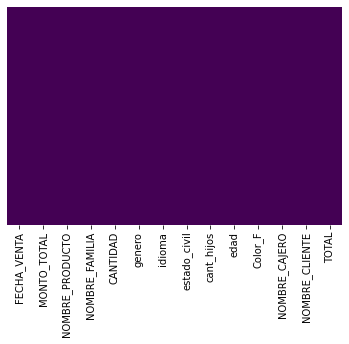

```python
sbn.heatmap(data.isnull(), cbar = False ,
            yticklabels = False , cmap = 'viridis')
```

```python
data.info()
```

```
<class 'pandas.core.frame.DataFrame'>
Int64Index: 1753 entries, 0 to 1752
Data columns (total 14 columns):
 #   Column           Non-Null Count  Dtype
---  ------           --------------  -----
 0   FECHA_VENTA      1753 non-null   object
 1   MONTO_TOTAL      1753 non-null   int64
 2   NOMBRE_PRODUCTO  1753 non-null   object
 3   NOMBRE_FAMILIA   1753 non-null   object
 4   CANTIDAD         1753 non-null   object
 5   genero           1753 non-null   object
 6   idioma           1753 non-null   object
 7   estado_civil     1753 non-null   object
 8   cant_hijos       1753 non-null   int64
 9   edad             1753 non-null   int64
 10  Color_F          1753 non-null   object
 11  NOMBRE_CAJERO    1753 non-null   object
 12  NOMBRE_CLIENTE   1753 non-null   object
 13  TOTAL            1753 non-null   int64
dtypes: int64(4), object(10)
memory usage: 205.4+ KB
```